# KDE

Shaine

2025-08-16

# 1 Uncertainty for ranks

Let $\theta_1, \theta_2, \dots, \theta_K$ be the true values of the parameters and let $\theta_{(1)}, \theta_{(2)}, \dots, \theta_{(K)}$ be the corresponding ordered parameter values.

Let $F_i$ be the CDF of $\hat{\theta}_{(i)} - \theta_{(i)}, i = 1, 2, \dots, K$. Note that $F_i \left( \hat{\theta}_{(i)} - \theta_{(i)}\right) \sim U(0,1)$. We want the quantity $u$ that satisfies :

$$P \left( 1-u < F_i \left ( \hat{\theta}_{(i)}-\theta_{(i)} \right) < u, \forall i\right) = 1 - \alpha
\\
\Longleftrightarrow
P \left(
\underset{1 \leq i \leq p} {\max}
\left\{ \max
\left\{
F_i
\left( \hat{\theta}_{(i)} - \theta_{(i)}
\right),
1-F_i
\left( \hat{\theta}_{(i)} - \theta_{(i)}
\right)
\right\}
\right\} < u
\right) = 1 - \alpha$$

Taking the inverse,

$$F_i^{-1} (1-u) < \hat{\theta}_{(i)}-\theta_{(i)} < F_i^{-1} (u), i = 1, 2, \dots, K$$

Isolating the true value,

$$F_i^{-1} (1-u) - \hat{\theta}_{(i)} < -\theta_{(i)} < F_i^{-1} (u)-\hat{\theta}_{(i)}
\\
\hat{\theta}_{(i)} - F_i^{-1} (u) < \theta_{(i)} < \hat{\theta}_{(i)} - F_i^{-1} (1-u)$$

Problem 1: We do not know $F_i^{-1}$ Problem 2: We do not know $u$

```r
library(dplyr)
alpha <- 0.10
K <- 10
df <- readRDS("../data/mean_travel_time_ranking_2011.rds")
calculate_variance <- function(moe) (moe/1.645)^2
dataset <- df[order(df$k),][1:K,]
dataset['variance'] <- lapply(dataset['moe_k'], calculate_variance)
rownames(dataset) <- dataset[,2]

dataset %>% select(c(k, theta_k, variance, rhat_k, S, moe_k)) %>% arrange(rhat_k)
```

```
                      k theta_k    variance rhat_k    S moe_k
6                Alaska   18.39 0.092386434      6 0.33   0.5
11             Arkansas   21.31 0.059127318     11 0.23   0.4
27              Alabama   23.94 0.014781829     27 0.14   0.2
32             Colorado   24.51 0.033259116     32 0.19   0.3
34              Arizona   24.76 0.014781829     34 0.15   0.2
35          Connecticut   24.98 0.033259116     35 0.19   0.3
36             Delaware   25.30 0.133036465     36 0.37   0.6
40              Florida   25.76 0.014781829     40 0.11   0.2
44           California   27.14 0.003695457     44 0.07   0.1
48 District of Columbia   30.10 0.092386434     48 0.32   0.5
```

## 1.1 Algorithm 1

### 1.1.1 Steps

Suppose the data consist of $\hat{\theta}_1, \hat{\theta}_1, \dots, \hat{\theta}_K$ and known values $\sigma_1^2, \sigma_2^2, \dots, \sigma_K^2$

1. Generate $\hat{\theta}^*_{bi} \sim \mathcal{N}(\hat{\theta}_i, \sigma_i^2)$

```r
library(knitr)
library(kableExtra)
library(foreach)
source('../R/algo1_helper.R')
B <- 1000

set.seed(4)
thetahat_star <- foreach(i = 1:K, .combine = cbind) %do% {
  foreach(b = 1:B, .combine = c) %do% {
    rnorm(1, mean = dataset[i, 'theta_k'], sd = dataset[i, 'S'])
  }
}

colnames(thetahat_star) <- paste0("thetahat_star", sprintf("%02d", 1:K))

kable(head(thetahat_star)) %>% kable_styling(bootstrap_options = "responsive")
```

| thetahat_star01 | thetahat_star02 | thetahat_star03 | thetahat_star04 | thetahat_star05 | thetahat_star06 | thetahat_star07 | thetahat_star08 | thetahat_star09 | thetahat_star10 |
| --- | --- | --- | --- | --- | --- | --- | --- | --- | --- |
| 23.97035 | 18.44828 | 24.55085 | 21.50700 | 27.13428 | 24.73272 | 25.07643 | 25.03256 | 29.76600 | 25.76016 |
| 23.86405 | 18.94739 | 24.76769 | 21.33926 | 27.08018 | 24.59708 | 24.91001 | 24.29844 | 30.42224 | 25.63526 |
| 24.06476 | 17.94538 | 24.92455 | 21.44136 | 27.07395 | 24.36332 | 25.00963 | 24.78359 | 29.62533 | 26.04541 |
| 24.02344 | 18.74496 | 24.72955 | 21.27403 | 27.22136 | 24.52473 | 25.02862 | 25.17049 | 29.91622 | 25.72272 |
| 24.16899 | 18.23945 | 24.69584 | 21.12062 | 27.05903 | 24.50817 | 25.12549 | 25.88046 | 29.71323 | 25.69105 |
| 24.03650 | 18.16512 | 24.69572 | 21.46085 | 27.04326 | 24.33356 | 25.23547 | 24.53924 | 29.84103 | 25.73988 |

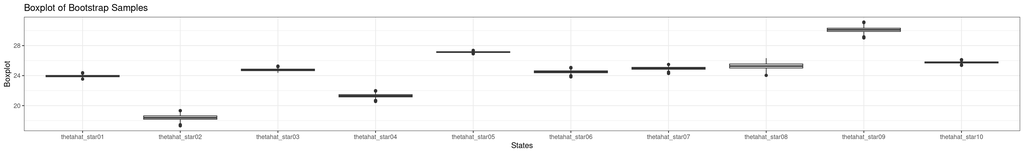

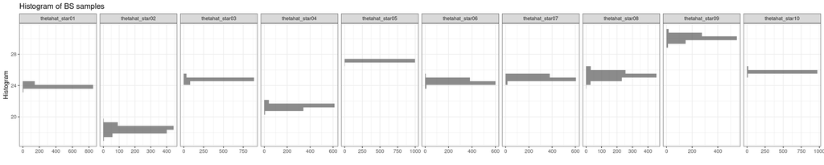

2. For each $b$, order the set $\left\{ \hat{\theta}^*_{b1}, \hat{\theta}^*_{b2}, \dots, \hat{\theta}^*_{bK} \right\}$ to obtain $\left\{ \hat{\theta}^*_{b(1)}, \hat{\theta}^*_{b(2)}, \dots, \hat{\theta}^*_{b(K)} \right\}$

```r
source('../R/algo1_helper.R')
sorted_thetahat_star <- t(apply(thetahat_star, 1, sort))
colnames(sorted_thetahat_star) <- paste0("sorted_thetahat_star", sprintf("%02d", 1:K))

kable(head(sorted_thetahat_star)) %>% kable_styling(bootstrap_options = "responsive")
```

| sorted_thetahat_star01 | sorted_thetahat_star02 | sorted_thetahat_star03 | sorted_thetahat_star04 | sorted_thetahat_star05 | sorted_thetahat_star06 | sorted_thetahat_star07 | sorted_thetahat_star08 | sorted_thetahat_star09 | sorted_thetahat_star10 |
| --- | --- | --- | --- | --- | --- | --- | --- | --- | --- |
| 18.44828 | 21.50700 | 23.97035 | 24.55085 | 24.73272 | 25.03256 | 25.07643 | 25.76016 | 27.13428 | 29.76600 |
| 18.94739 | 21.33926 | 23.86405 | 24.29844 | 24.59708 | 24.76769 | 24.91001 | 25.63526 | 27.08018 | 30.42224 |
| 17.94538 | 21.44136 | 24.06476 | 24.36332 | 24.78359 | 24.92455 | 25.00963 | 26.04541 | 27.07395 | 29.62533 |
| 18.74496 | 21.27403 | 24.02344 | 24.52473 | 24.72955 | 25.02862 | 25.17049 | 25.72272 | 27.22136 | 29.91622 |
| 18.23945 | 21.12062 | 24.16899 | 24.50817 | 24.69584 | 25.12549 | 25.69105 | 25.88046 | 27.05903 | 29.71323 |
| 18.16512 | 21.46085 | 24.03650 | 24.33356 | 24.53924 | 24.69572 | 25.23547 | 25.73988 | 27.04326 | 29.84103 |

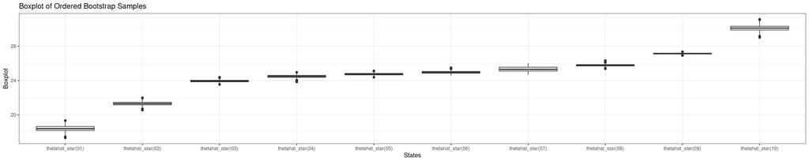

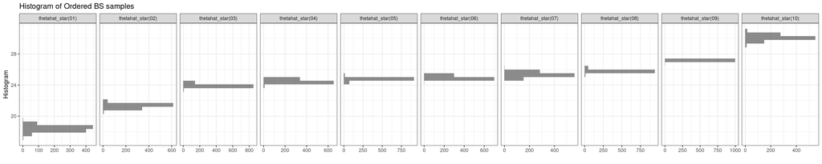

3. For each $b$, compute the difference $r^*_{bi} = \hat{\theta}^*_{b(i)} - \hat{\theta}_{(i)}, i = 1, 2, \dots, K$

```r
rstar <- sorted_thetahat_star - matrix(sort(t(dataset['theta_k'])),B, K, byrow=TRUE)
#rstar <- sweep(sorted_thetahat_star, 2, colMeans(sorted_thetahat_star), FUN = "-")
colnames(rstar) <- paste0("rstar", sprintf("%02d", 1:K))
kable(head(rstar)) %>% kable_styling(bootstrap_options = "responsive")
```

| rstar01 | rstar02 | rstar03 | rstar04 | rstar05 | rstar06 | rstar07 | rstar08 | rstar09 | rstar10 |
| --- | --- | --- | --- | --- | --- | --- | --- | --- | --- |
| 0.0582826 | 0.1970047 | 0.0303457 | 0.0408461 | -0.0272842 | 0.0525642 | -0.2235705 | 0.0001586 | -0.0057185 | -0.3339988 |
| 0.5573851 | 0.0292625 | -0.0759490 | -0.2115636 | -0.1629242 | -0.2123088 | -0.3899937 | -0.1247412 | -0.0598186 | 0.3222397 |
| -0.4446229 | 0.1313593 | 0.1247603 | -0.1466784 | 0.0235856 | -0.0554470 | -0.2903685 | 0.2854073 | -0.0660521 | -0.4746657 |
| 0.3549554 | -0.0359693 | 0.0834373 | 0.0147315 | -0.0304461 | 0.0486203 | -0.1295063 | -0.0372777 | 0.0813613 | -0.1837839 |
| -0.1505490 | -0.1893781 | 0.2289865 | -0.0018310 | -0.0641641 | 0.1454946 | 0.3910456 | 0.1204594 | -0.0809706 | -0.3867705 |
| -0.2248767 | 0.1508490 | 0.0964986 | -0.1764428 | -0.2207635 | -0.2842775 | -0.0645311 | -0.0201179 | -0.0967378 | -0.2589675 |

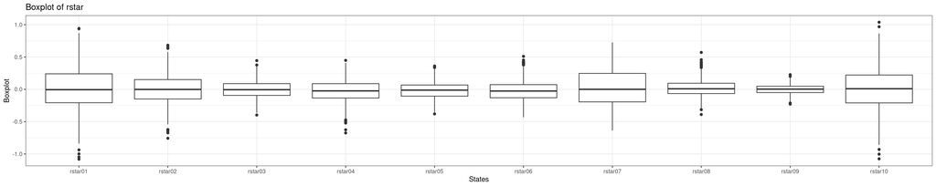

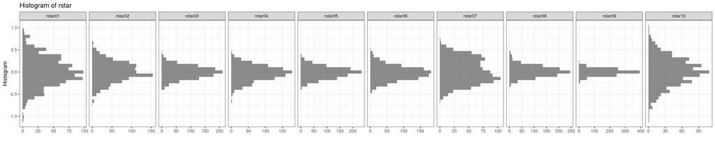

4. Let $F_i$ be the density of $\hat{\theta}_{(i)} - \theta_{(i)}, i = 1, 2, \dots, K$. Estimate each $F_i$ bu computing $\hat{F}_i$ using KDE based on $r^*_{1i}, r^*_{2i}, \dots, r^*_{Bi}$, that is

$$\hat{F}_i(x) = \frac{1}{B}\sum^B_{\alpha=1} \Phi \left( \frac{x-r^*_{\alpha i}}{h_i} \right), \ \ \ h_i=0.9\min\{S_i, IQR_i/1.34\}\ B^{-1/5}$$

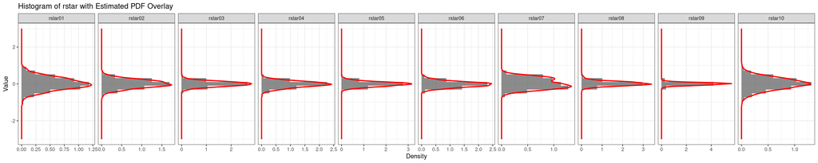

5. Compute $Y^*_{bi}= \hat{F}_i(r^*_{bi})$ for each $b = 1, 2, \dots, B$ and $i = 1, 2, \dots, K$ (PIT part)

```r
Ystar <- foreach(i = 1:K, .combine = cbind) %do% {
  sapply(rstar[,i], Fhat[[i]])
}
colnames(Ystar) <- paste0("Ystar", sprintf("%02d", 1:K))
kable(head(Ystar)) %>% kable_styling(bootstrap_options = "responsive")
```

| Ystar01 | Ystar02 | Ystar03 | Ystar04 | Ystar05 | Ystar06 | Ystar07 | Ystar08 | Ystar09 | Ystar10 |
| --- | --- | --- | --- | --- | --- | --- | --- | --- | --- |
| 0.5693040 | 0.8000465 | 0.5968145 | 0.6472721 | 0.4504055 | 0.6925261 | 0.2133116 | 0.4688549 | 0.4560673 | 0.1465569 |
| 0.9468807 | 0.5495232 | 0.3055657 | 0.1504418 | 0.1301247 | 0.1236215 | 0.0603134 | 0.1189783 | 0.2147213 | 0.8344131 |
| 0.0911755 | 0.7084145 | 0.8242928 | 0.2374368 | 0.6104881 | 0.4311526 | 0.1399805 | 0.9769509 | 0.1918892 | 0.0744012 |
| 0.8440697 | 0.4411908 | 0.7356676 | 0.5886576 | 0.4407411 | 0.6833824 | 0.3350193 | 0.3431156 | 0.8784760 | 0.2716876 |
| 0.3193124 | 0.2016584 | 0.9587115 | 0.5498112 | 0.3448252 | 0.8589910 | 0.8923287 | 0.8088328 | 0.1424415 | 0.1154256 |
| 0.2404437 | 0.7372194 | 0.7656102 | 0.1930720 | 0.0594369 | 0.0517225 | 0.4202395 | 0.4001552 | 0.0977235 | 0.2028801 |

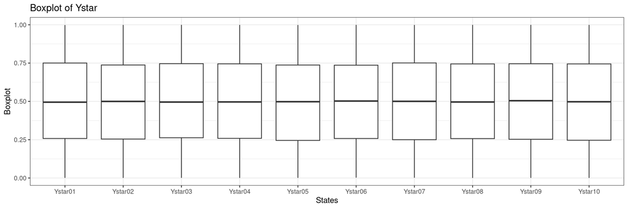

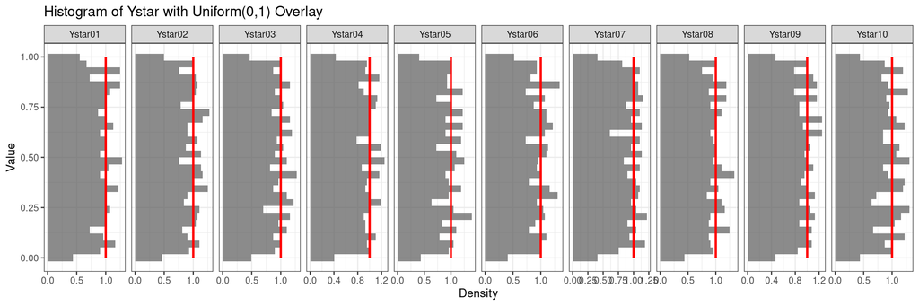

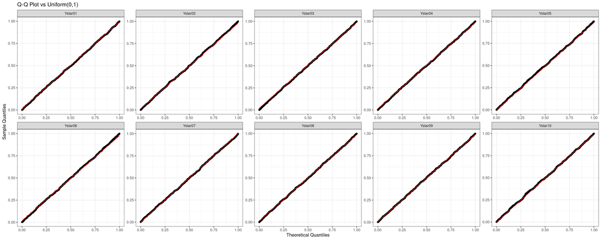

```r
#apply(dat10, 2, function(col) ks.test(col, "punif", min = 0, max = 1))
```

6. Compute $U^*_b = \underset{1 \leq i \leq p} {\max} \{\max\{Y^*_{bi}, 1-Y^*_{bi}\}\}$ for $b = 1, 2, \dots, B$.

Due to PIT result in item 5, we can be sure that $\max\{Y^*_{bi}, 1-Y^*_{bi}\} \geq 0.5$ since $0 \leq Y^*_{bi}= \hat{F}_i(r^*_{bi}) \leq 1$. It follows that $U^*_b \geq 0.5$

```r
Ustar <- apply(apply(Ystar, MARGIN = c(1, 2), FUN = get_inner_max), 1, max)
head(Ustar)
```

[1] 0.8534431 0.9468807 0.9769509 0.8784760 0.9587115 0.9482775

```r
summary(Ustar)
```

```
   Min. 1st Qu.  Median    Mean 3rd Qu.    Max.
 0.7278  0.9245  0.9615  0.9483  0.9831  0.9995
```

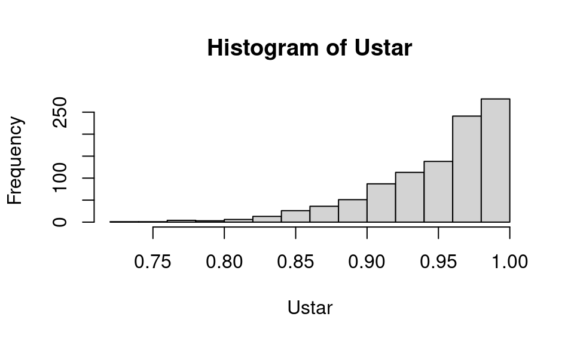

```r
hist(Ustar)
```

7. Compute $\hat{u}$ as the $(1-\alpha)$-sample quantile of $U^*_1, U^*_2, \dots, U^*_B$

```r
# what is the value of uhat ST when we repeat the experiment n times (calculate F(r) in all those times), we are sure that the intervals (1-u, u) jointly contain Y=F(r), 1-alpha of the time
uhat <- quantile(Ustar, probs = 1 - alpha)
uhat
```

```
      90%
0.9931013
```

```r
# definition of quantile
length(Ustar[Ustar<= uhat])/length(Ustar)
```

```
[1] 0.9
```

8. The join confidence region is calculated

```r
library("dplyr")
library("GoFKernel")

sorted_indices <- order(dataset$theta_k)
sorted_dataset <- dataset[sorted_indices, ]
sorted_theta_k <- sorted_dataset$theta_k

Fhat.inv <- lapply(Fhat, function(F) inverse(F, lower = -100, upper = 100))

sorted_dataset$Fhat.inv_u    <- sapply(1:K, function(i) Fhat.inv[[i]](uhat))
sorted_dataset$Fhat.inv_1_u  <- sapply(1:K, function(i) Fhat.inv[[i]](1 - uhat))

sorted_dataset$kde_ci_lower <- sorted_theta_k - sorted_dataset$Fhat.inv_u
sorted_dataset$kde_ci_upper <- sorted_theta_k - sorted_dataset$Fhat.inv_1_u

sorted_dataset$original_index <- sorted_indices

interval_table <- sorted_dataset %>%
  select(k = k,
         theta_k = theta_k,
         kde_ci_lower = kde_ci_lower,
         kde_ci_upper = kde_ci_upper)

kable(interval_table, digits = 4) %>%
  kable_styling(bootstrap_options = "responsive")
```

|  | k | theta_k | kde_ci_lower | kde_ci_upper |
| --- | --- | --- | --- | --- |
| 6 | Alaska | 18.39 | 17.5474 | 19.2044 |
| 11 | Arkansas | 21.31 | 20.7636 | 21.8861 |
| 27 | Alabama | 23.94 | 23.6043 | 24.2851 |
| 32 | Colorado | 24.51 | 24.1460 | 24.9843 |
| 34 | Arizona | 24.76 | 24.4461 | 25.0859 |
| 35 | Connecticut | 24.98 | 24.5720 | 25.3788 |
| 36 | Delaware | 25.30 | 24.6823 | 25.8668 |
| 40 | Florida | 25.76 | 25.3712 | 26.0335 |
| 44 | California | 27.14 | 26.9680 | 27.3243 |
| 48 | District of Columbia | 30.10 | 29.3134 | 30.9201 |

### 1.1.2 Full function

#### 1.1.2.1 Sample usage

```r
source('../R/algo1_helper.R')

alpha <- 0.10
K <- 10
B <- 1000
df <- readRDS("../data/mean_travel_time_ranking_2011.rds")

# filter accdg to K
dataset <- df[order(df$k),][1:K,]

#dataset_or <- generate_synthetic_dataset(K = K, seed = 42) #TRUE
#dataset<-dataset_or
theta_hat <- foreach(i = 1:K,
                     .combine = cbind) %do% {
                       rnorm(1,
                             mean = dataset[i, 'theta_k'],
                             sd = dataset[i, 'S'])
                     } # SAMPLE

sort_reference <- data.frame(theta = dataset$theta_k,
                             theta_hat = t(theta_hat))

dataset$theta_k <- NULL # remove theta k from the dataset
dataset$theta_k <- t(theta_hat)
# run for K = 10
output_for_k10 <- run_algorithm1(B, dataset, seed = 4, alpha = 0.1)
output_for_k10
```

#### 1.1.2.2 Application to diff K

```r
B<-1000
source('../R/algo1_helper.R')

alpha <- 0.10
K <- 10
B <- 1000
df <- readRDS("../data/mean_travel_time_ranking_2011.rds")


for (K in c(10, 20, 30, 40, 51)) {
  # filtering the dataset
  dataset <- df[order(df$k),][1:K,]
  # running the algo1
  result <- run_algorithm1(B, dataset)$interval_table
  # saving the file
  filename <- paste0("../data/kde_intervals_", K, ".rds")
  saveRDS(result, file = filename)
}
```

```r
output <- list()

# original columns: "rhat_k","k","theta_k","kde_ci_lower,kde_ci_upper"
# the rest are added on this chunk

for (K in c(10, 20, 30, 40, 51)) {
  # reading the outputs saved previously
  filename <- paste0("../data/kde_intervals_", K, ".rds")
  output[[K]] <- readRDS(filename)

  # converting into tuples
  tuple_list <- t(apply(output[[K]][,c('kde_ci_lower', 'kde_ci_upper')], 1, function(row) as.numeric(row)))

  # calculating the min from ranks
  output[[K]]['kde_rank_lower'] <- sapply(1:K, function(x) min(get_ranks(x, tuple_list)$ranks))

  # calculating the max from ranks
  output[[K]]['kde_rank_upper'] <- sapply(1:K, function(x) max(get_ranks(x, tuple_list)$ranks))

  # cardinality based on lambdaOK
  output[[K]]['kde_Lambda_Ok_length'] <- sapply(1:K, function(x) length(get_ranks(x, tuple_list)$Lambda_Ok))

  # cardinality based on computed ranks
  output[[K]]['kde_rank_range_length'] <- sapply(1:K, function(x) length(get_ranks(x, tuple_list)$ranks))
 # print(paste("**** Output shown for K=", K, "****"))

  # adding something similar to rhatk only for K=10
  output[[K]]['sample_rank'] <- rank(output[[K]]$theta_k, ties.method = "max")
  #cat("\n\n---\n\n")
}
```

##### 1.1.2.2.1 K = 10

| k | theta_k | kde_ci_lower | kde_ci_upper | original_index | kde_rank_lower | kde_rank_upper | kde_Lambda_Ok_length | kde_rank_range_length | sample_rank |
| --- | --- | --- | --- | --- | --- | --- | --- | --- | --- |
| Alaska | 18.39 | 17.47290 | 19.21137 | 2 | 1 | 1 | 0 | 1 | 1 |
| Arkansas | 21.31 | 20.71081 | 21.90885 | 4 | 2 | 2 | 0 | 1 | 2 |
| Alabama | 23.94 | 22.94000 | 24.94000 | 1 | 3 | 8 | 5 | 6 | 3 |
| Colorado | 24.51 | 23.51000 | 25.51000 | 6 | 3 | 8 | 5 | 6 | 4 |
| Arizona | 24.76 | 23.76000 | 25.76000 | 3 | 3 | 8 | 5 | 6 | 5 |
| Connecticut | 24.98 | 23.98000 | 25.98000 | 7 | 3 | 8 | 5 | 6 | 6 |
| Delaware | 25.30 | 24.30000 | 26.29309 | 8 | 3 | 9 | 6 | 7 | 7 |
| Florida | 25.76 | 24.76000 | 26.76000 | 10 | 3 | 9 | 6 | 7 | 8 |
| California | 27.14 | 26.14000 | 28.14000 | 5 | 7 | 9 | 2 | 3 | 9 |
| District of Columbia | 30.10 | 29.36000 | 30.85927 | 9 | 10 | 10 | 0 | 1 | 10 |

##### 1.1.2.2.2 K = 20

| k | theta_k | kde_ci_lower | kde_ci_upper | original_index | kde_rank_lower | kde_rank_upper | kde_Lambda_Ok_length | kde_rank_range_length | sample_rank |
| --- | --- | --- | --- | --- | --- | --- | --- | --- | --- |
| Alaska | 18.39 | 17.39000 | 19.28572 | 2 | 1 | 4 | 3 | 4 | 1 |
| Iowa | 18.77 | 17.77000 | 19.77000 | 16 | 1 | 4 | 3 | 4 | 2 |
| Kansas | 18.90 | 17.90000 | 19.90000 | 17 | 1 | 4 | 3 | 4 | 3 |
| Idaho | 19.66 | 18.98293 | 20.28887 | 13 | 1 | 4 | 3 | 4 | 4 |
| Arkansas | 21.31 | 20.64732 | 21.97140 | 4 | 5 | 6 | 1 | 2 | 5 |
| Kentucky | 22.86 | 21.86000 | 23.86000 | 18 | 5 | 12 | 7 | 8 | 6 |
| Maine | 23.41 | 22.41000 | 24.41000 | 20 | 6 | 14 | 8 | 9 | 7 |
| Indiana | 23.45 | 22.46059 | 24.45000 | 15 | 6 | 14 | 8 | 9 | 8 |
| Alabama | 23.94 | 22.94000 | 24.94000 | 1 | 6 | 16 | 10 | 11 | 9 |
| Colorado | 24.51 | 23.51000 | 25.51000 | 6 | 6 | 16 | 10 | 11 | 10 |
| Louisiana | 24.54 | 23.54000 | 25.54000 | 19 | 6 | 16 | 10 | 11 | 11 |
| Arizona | 24.76 | 23.76000 | 25.76000 | 3 | 6 | 16 | 10 | 11 | 12 |
| Connecticut | 24.98 | 23.98000 | 25.98000 | 7 | 7 | 16 | 9 | 10 | 13 |
| Delaware | 25.30 | 24.32051 | 26.29993 | 8 | 7 | 18 | 11 | 12 | 14 |
| Hawaii | 25.69 | 24.69000 | 26.69000 | 12 | 9 | 18 | 9 | 10 | 15 |
| Florida | 25.76 | 24.76000 | 26.76000 | 10 | 9 | 18 | 9 | 10 | 16 |
| Georgia | 27.11 | 26.11000 | 28.11000 | 11 | 14 | 19 | 5 | 6 | 17 |
| California | 27.14 | 26.14000 | 28.14000 | 5 | 14 | 19 | 5 | 6 | 18 |
| Illinois | 28.17 | 27.17000 | 29.17000 | 14 | 17 | 19 | 2 | 3 | 19 |
| District of Columbia | 30.10 | 29.30526 | 30.91544 | 9 | 20 | 20 | 0 | 1 | 20 |

##### 1.1.2.2.3 K = 30

| k | theta_k | kde_ci_lower | kde_ci_upper | original_index | kde_rank_lower | kde_rank_upper | kde_Lambda_Ok_length | kde_rank_range_length | sample_rank |
| --- | --- | --- | --- | --- | --- | --- | --- | --- | --- |
| Nebraska | 18.06 | 17.06000 | 18.81253 | 28 | 1 | 5 | 4 | 5 | 1 |
| Montana | 18.18 | 17.18000 | 19.18000 | 27 | 1 | 6 | 5 | 6 | 2 |
| Alaska | 18.39 | 17.39000 | 19.39000 | 2 | 1 | 6 | 5 | 6 | 3 |
| Iowa | 18.77 | 17.77000 | 19.77000 | 16 | 1 | 6 | 5 | 6 | 4 |
| Kansas | 18.90 | 17.90000 | 19.90000 | 17 | 1 | 6 | 5 | 6 | 5 |
| Idaho | 19.66 | 18.96322 | 20.31002 | 13 | 2 | 6 | 4 | 5 | 6 |
| Arkansas | 21.31 | 20.62090 | 21.99530 | 4 | 7 | 9 | 2 | 3 | 7 |
| Kentucky | 22.86 | 21.86000 | 23.86000 | 18 | 7 | 19 | 12 | 13 | 8 |
| Minnesota | 22.99 | 21.99000 | 23.99000 | 24 | 7 | 20 | 13 | 14 | 9 |
| Missouri | 23.07 | 22.07000 | 24.07000 | 26 | 8 | 20 | 12 | 13 | 10 |
| Maine | 23.41 | 22.41000 | 24.41000 | 20 | 8 | 21 | 13 | 14 | 11 |
| Indiana | 23.45 | 22.45000 | 24.45000 | 15 | 8 | 21 | 13 | 14 | 12 |
| Mississippi | 23.86 | 22.86000 | 24.86000 | 25 | 8 | 22 | 14 | 15 | 13 |
| Alabama | 23.94 | 22.94000 | 24.94000 | 1 | 8 | 22 | 14 | 15 | 14 |
| Nevada | 24.10 | 23.10000 | 25.10000 | 29 | 8 | 23 | 15 | 16 | 15 |
| Michigan | 24.11 | 23.11000 | 25.11000 | 23 | 8 | 23 | 15 | 16 | 16 |
| Colorado | 24.51 | 23.51000 | 25.51000 | 6 | 8 | 23 | 15 | 16 | 17 |
| Louisiana | 24.54 | 23.54000 | 25.54000 | 19 | 8 | 23 | 15 | 16 | 18 |
| Arizona | 24.76 | 23.76000 | 25.76000 | 3 | 8 | 23 | 15 | 16 | 19 |
| Connecticut | 24.98 | 23.98000 | 25.98000 | 7 | 9 | 24 | 15 | 16 | 20 |
| Delaware | 25.30 | 24.32051 | 26.29993 | 8 | 11 | 26 | 15 | 16 | 21 |
| Hawaii | 25.69 | 24.69000 | 26.69000 | 12 | 13 | 26 | 13 | 14 | 22 |
| Florida | 25.76 | 25.02110 | 26.76000 | 10 | 15 | 26 | 11 | 12 | 23 |
| New Hampshire | 26.90 | 25.90000 | 27.77636 | 30 | 20 | 28 | 8 | 9 | 24 |
| Georgia | 27.11 | 26.11000 | 28.11000 | 11 | 21 | 28 | 7 | 8 | 25 |
| California | 27.14 | 26.14000 | 28.14000 | 5 | 21 | 28 | 7 | 8 | 26 |
| Massachusetts | 27.99 | 26.99000 | 28.99000 | 22 | 24 | 28 | 4 | 5 | 27 |
| Illinois | 28.17 | 27.17000 | 29.17000 | 14 | 24 | 28 | 4 | 5 | 28 |
| District of Columbia | 30.10 | 29.27750 | 30.93853 | 9 | 29 | 29 | 0 | 1 | 29 |
| Maryland | 32.21 | 31.21000 | 33.21000 | 21 | 30 | 30 | 0 | 1 | 30 |

##### 1.1.2.2.4 K = 40

| k | theta_k | kde_ci_lower | kde_ci_upper | original_index | kde_rank_lower | kde_rank_upper | kde_Lambda_Ok_length | kde_rank_range_length | sample_rank |
| --- | --- | --- | --- | --- | --- | --- | --- | --- | --- |
| North Dakota | 16.91 | 15.95149 | 18.02974 | 35 | 1 | 6 | 5 | 6 | 1 |
| Nebraska | 18.06 | 17.06000 | 18.81919 | 28 | 1 | 6 | 5 | 6 | 2 |
| Montana | 18.18 | 17.18000 | 19.18000 | 27 | 1 | 7 | 6 | 7 | 3 |
| Alaska | 18.39 | 17.39000 | 19.39000 | 2 | 1 | 7 | 6 | 7 | 4 |
| Iowa | 18.77 | 17.77000 | 19.77000 | 16 | 1 | 7 | 6 | 7 | 5 |
| Kansas | 18.90 | 17.90000 | 19.90000 | 17 | 1 | 7 | 6 | 7 | 6 |
| Idaho | 19.66 | 18.95383 | 20.32250 | 13 | 3 | 9 | 6 | 7 | 7 |
| Oklahoma | 21.13 | 20.13000 | 21.77828 | 37 | 7 | 11 | 4 | 5 | 8 |
| Arkansas | 21.31 | 20.31000 | 22.31000 | 4 | 7 | 15 | 8 | 9 | 9 |
| New Mexico | 21.43 | 20.65878 | 22.43000 | 32 | 8 | 18 | 10 | 11 | 10 |
| Oregon | 22.54 | 21.54000 | 23.54000 | 38 | 8 | 24 | 16 | 17 | 11 |
| Kentucky | 22.86 | 21.86000 | 23.86000 | 18 | 9 | 26 | 17 | 18 | 12 |
| Minnesota | 22.99 | 21.99000 | 23.99000 | 24 | 9 | 27 | 18 | 19 | 13 |
| Missouri | 23.07 | 22.07000 | 24.07000 | 26 | 9 | 27 | 18 | 19 | 14 |
| Ohio | 23.12 | 22.12000 | 24.12000 | 36 | 9 | 27 | 18 | 19 | 15 |
| Rhode Island | 23.36 | 22.36000 | 24.36000 | 40 | 10 | 28 | 18 | 19 | 16 |
| North Carolina | 23.37 | 22.37000 | 24.37000 | 34 | 10 | 28 | 18 | 19 | 17 |
| Maine | 23.41 | 22.41000 | 24.41000 | 20 | 10 | 28 | 18 | 19 | 18 |
| Indiana | 23.45 | 22.45000 | 24.45000 | 15 | 11 | 28 | 17 | 18 | 19 |
| Mississippi | 23.86 | 22.86000 | 24.86000 | 25 | 11 | 30 | 19 | 20 | 20 |
| Alabama | 23.94 | 22.94000 | 24.94000 | 1 | 11 | 31 | 20 | 21 | 21 |
| Nevada | 24.10 | 23.10000 | 25.10000 | 29 | 11 | 31 | 20 | 21 | 22 |
| Michigan | 24.11 | 23.11000 | 25.11000 | 23 | 11 | 31 | 20 | 21 | 23 |
| Colorado | 24.51 | 23.51000 | 25.51000 | 6 | 11 | 31 | 20 | 21 | 24 |
| Louisiana | 24.54 | 23.54000 | 25.54000 | 19 | 12 | 31 | 19 | 20 | 25 |
| Arizona | 24.76 | 23.76000 | 25.76000 | 3 | 12 | 31 | 19 | 20 | 26 |
| Connecticut | 24.98 | 23.98000 | 25.98000 | 7 | 13 | 32 | 19 | 20 | 27 |
| Delaware | 25.30 | 24.30000 | 26.29994 | 8 | 16 | 34 | 18 | 19 | 28 |
| Hawaii | 25.69 | 24.69000 | 26.69000 | 12 | 20 | 34 | 14 | 15 | 29 |
| Florida | 25.76 | 24.76000 | 26.76000 | 10 | 20 | 34 | 14 | 15 | 30 |
| Pennsylvania | 25.92 | 24.92000 | 26.92000 | 39 | 21 | 34 | 13 | 14 | 31 |
| New Hampshire | 26.90 | 25.90000 | 27.78590 | 30 | 27 | 36 | 9 | 10 | 32 |
| Georgia | 27.11 | 26.11000 | 28.11000 | 11 | 28 | 36 | 8 | 9 | 33 |
| California | 27.14 | 26.14000 | 28.14000 | 5 | 28 | 36 | 8 | 9 | 34 |
| Massachusetts | 27.99 | 26.99000 | 28.99000 | 22 | 32 | 36 | 4 | 5 | 35 |
| Illinois | 28.17 | 27.17000 | 29.17000 | 14 | 32 | 36 | 4 | 5 | 36 |
| District of Columbia | 30.10 | 29.46727 | 30.94639 | 9 | 37 | 39 | 2 | 3 | 37 |
| New Jersey | 30.53 | 29.53000 | 31.53000 | 31 | 37 | 40 | 3 | 4 | 38 |
| New York | 31.50 | 30.50000 | 32.50000 | 33 | 37 | 40 | 3 | 4 | 39 |
| Maryland | 32.21 | 31.21000 | 33.21000 | 21 | 38 | 40 | 2 | 3 | 40 |

##### 1.1.2.2.5 K = 51

| k | theta_k | kde_ci_lower | kde_ci_upper | original_index | kde_rank_lower | kde_rank_upper | kde_Lambda_Ok_length | kde_rank_range_length | sample_rank |
| --- | --- | --- | --- | --- | --- | --- | --- | --- | --- |
| South Dakota | 16.86 | 15.86000 | 17.96249 | 42 | 1 | 8 | 7 | 8 | 1 |
| North Dakota | 16.91 | 15.97285 | 17.90997 | 35 | 1 | 8 | 7 | 8 | 2 |
| Nebraska | 18.06 | 17.06000 | 19.16444 | 28 | 1 | 9 | 8 | 9 | 3 |
| Wyoming | 18.10 | 17.10000 | 19.10000 | 51 | 1 | 9 | 8 | 9 | 4 |
| Montana | 18.18 | 17.19124 | 19.18000 | 27 | 1 | 9 | 8 | 9 | 5 |
| Alaska | 18.39 | 17.39000 | 19.39000 | 2 | 1 | 9 | 8 | 9 | 6 |
| Iowa | 18.77 | 17.77000 | 19.77000 | 16 | 1 | 9 | 8 | 9 | 7 |
| Kansas | 18.90 | 17.90021 | 19.90000 | 17 | 1 | 9 | 8 | 9 | 8 |
| Idaho | 19.66 | 18.94338 | 20.33978 | 13 | 3 | 11 | 8 | 9 | 9 |
| Oklahoma | 21.13 | 20.13000 | 22.07236 | 37 | 9 | 19 | 10 | 11 | 10 |
| Arkansas | 21.31 | 20.31000 | 22.31000 | 4 | 9 | 20 | 11 | 12 | 11 |
| New Mexico | 21.43 | 20.43000 | 22.43000 | 32 | 10 | 23 | 13 | 14 | 12 |
| Utah | 21.61 | 20.61000 | 22.61000 | 45 | 10 | 24 | 14 | 15 | 13 |
| Wisconsin | 21.92 | 20.92000 | 22.92000 | 50 | 10 | 26 | 16 | 17 | 14 |
| Vermont | 21.94 | 20.94000 | 22.94000 | 46 | 10 | 26 | 16 | 17 | 15 |
| Oregon | 22.54 | 21.54000 | 23.54000 | 38 | 10 | 31 | 21 | 22 | 16 |
| Kentucky | 22.86 | 21.86000 | 23.86000 | 18 | 10 | 34 | 24 | 25 | 17 |
| Minnesota | 22.99 | 21.99000 | 23.99000 | 24 | 10 | 35 | 25 | 26 | 18 |
| Missouri | 23.07 | 22.07000 | 24.07000 | 26 | 10 | 35 | 25 | 26 | 19 |
| Ohio | 23.12 | 22.12000 | 24.12000 | 36 | 11 | 35 | 24 | 25 | 20 |
| Rhode Island | 23.36 | 22.36000 | 24.36000 | 40 | 12 | 36 | 24 | 25 | 21 |
| North Carolina | 23.37 | 22.37000 | 24.37000 | 34 | 12 | 36 | 24 | 25 | 22 |
| Maine | 23.41 | 22.41000 | 24.41000 | 20 | 12 | 36 | 24 | 25 | 23 |
| Indiana | 23.45 | 22.45000 | 24.45000 | 15 | 13 | 36 | 23 | 24 | 24 |
| South Carolina | 23.61 | 22.61000 | 24.61000 | 41 | 14 | 38 | 24 | 25 | 25 |
| Mississippi | 23.86 | 22.86000 | 24.86000 | 25 | 14 | 40 | 26 | 27 | 26 |
| Alabama | 23.94 | 22.94000 | 24.94000 | 1 | 16 | 41 | 25 | 26 | 27 |
| Nevada | 24.10 | 23.10000 | 25.10000 | 29 | 16 | 41 | 25 | 26 | 28 |
| Michigan | 24.11 | 23.11000 | 25.11000 | 23 | 16 | 41 | 25 | 26 | 29 |
| Tennessee | 24.23 | 23.23000 | 25.23000 | 43 | 16 | 41 | 25 | 26 | 30 |
| Colorado | 24.51 | 23.51000 | 25.51000 | 6 | 16 | 41 | 25 | 26 | 31 |
| Louisiana | 24.54 | 23.54000 | 25.54000 | 19 | 17 | 41 | 24 | 25 | 32 |
| Arizona | 24.76 | 23.76000 | 25.76000 | 3 | 17 | 41 | 24 | 25 | 33 |
| Texas | 24.82 | 23.82000 | 25.82000 | 44 | 17 | 41 | 24 | 25 | 34 |
| Connecticut | 24.98 | 23.98000 | 25.98000 | 7 | 18 | 42 | 24 | 25 | 35 |
| Delaware | 25.30 | 24.30000 | 26.30000 | 8 | 21 | 44 | 23 | 24 | 36 |
| Washington | 25.51 | 24.51000 | 26.51000 | 48 | 25 | 44 | 19 | 20 | 37 |
| West Virginia | 25.58 | 24.58000 | 26.58000 | 49 | 25 | 44 | 19 | 20 | 38 |
| Hawaii | 25.69 | 24.69000 | 26.69000 | 12 | 26 | 44 | 18 | 19 | 39 |
| Florida | 25.76 | 24.76000 | 26.76000 | 10 | 26 | 45 | 19 | 20 | 40 |
| Pennsylvania | 25.92 | 24.92000 | 26.92000 | 39 | 27 | 45 | 18 | 19 | 41 |
| New Hampshire | 26.90 | 25.90000 | 27.79646 | 30 | 35 | 47 | 12 | 13 | 42 |
| Georgia | 27.11 | 26.11000 | 28.11000 | 11 | 36 | 47 | 11 | 12 | 43 |
| California | 27.14 | 26.14000 | 28.14000 | 5 | 36 | 47 | 11 | 12 | 44 |
| Virginia | 27.74 | 26.74000 | 28.74000 | 47 | 40 | 47 | 7 | 8 | 45 |
| Massachusetts | 27.99 | 26.99000 | 28.99000 | 22 | 42 | 47 | 5 | 6 | 46 |
| Illinois | 28.17 | 27.17000 | 29.17000 | 14 | 42 | 47 | 5 | 6 | 47 |
| District of Columbia | 30.10 | 29.45439 | 30.95935 | 9 | 48 | 50 | 2 | 3 | 48 |
| New Jersey | 30.53 | 29.53000 | 31.53000 | 31 | 48 | 51 | 3 | 4 | 49 |
| New York | 31.50 | 30.50000 | 32.50000 | 33 | 48 | 51 | 3 | 4 | 50 |
| Maryland | 32.21 | 31.21000 | 33.21000 | 21 | 49 | 51 | 2 | 3 | 51 |

### 1.1.3 Plots

#### 1.1.3.1 KDE

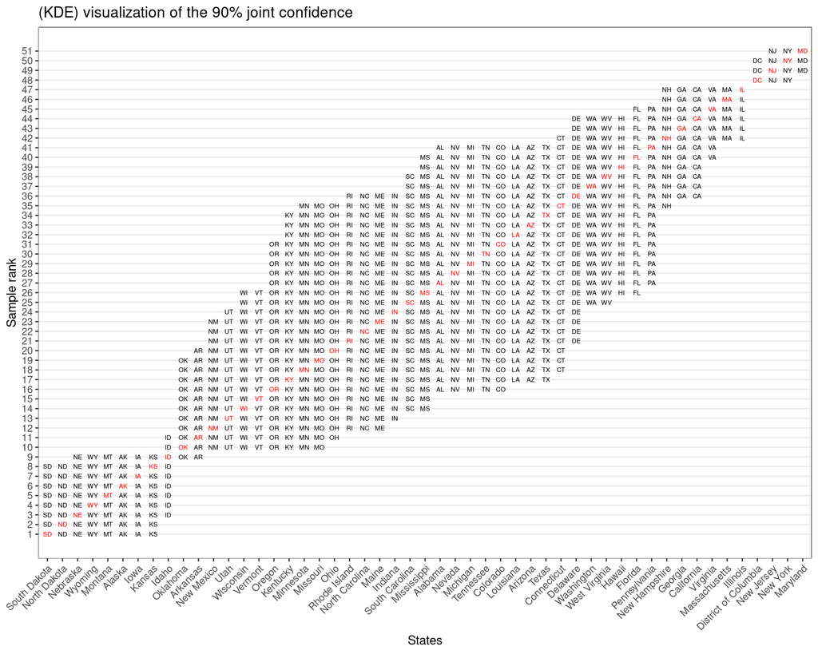

#### 1.1.3.2 IND

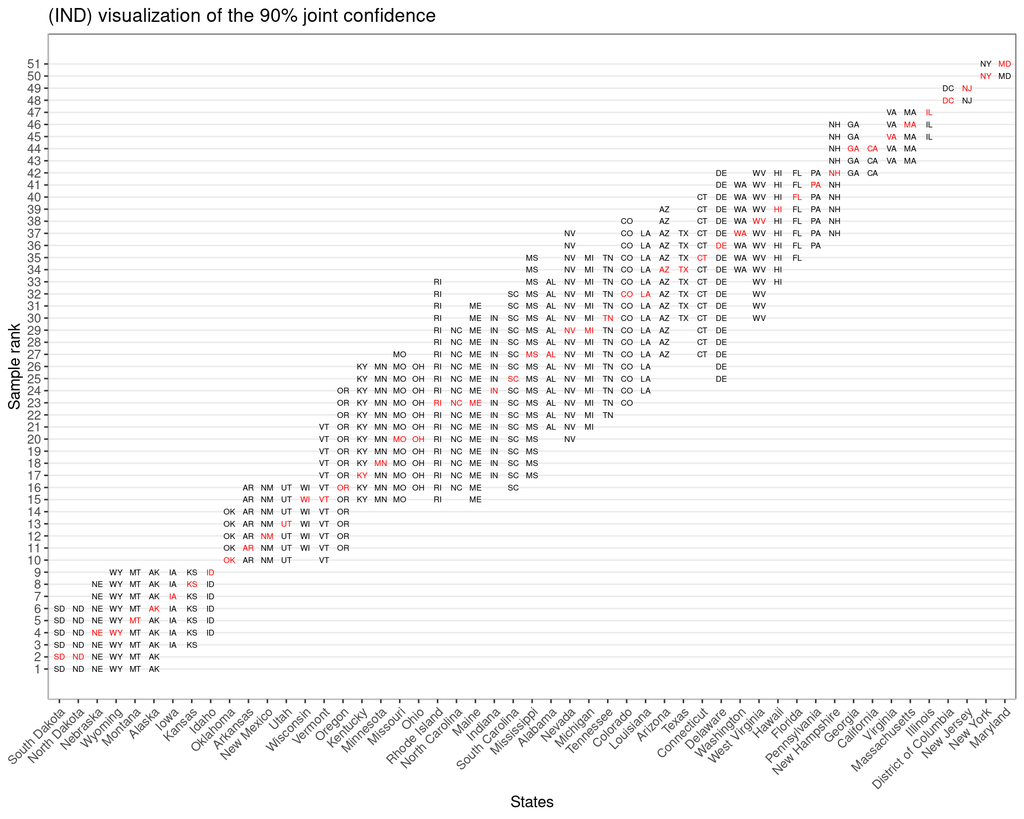

## 1.2 T1, T2, T3

```r
tuple_list <- t(apply(df[,c('bonf_ci_lower', 'bonf_ci_upper')], 1, function(row) as.numeric(row)))
df['bonf_Lambda_Ok_length'] <- sapply(1:K, function(x) length(get_ranks(x, tuple_list)$Lambda_Ok))
df['bonf_rank_range_length'] <- sapply(1:K, function(x) length(get_ranks(x, tuple_list)$ranks))

tuple_list <- t(apply(df[,c('ind_ci_lower', 'ind_ci_upper')], 1, function(row) as.numeric(row)))
df['ind_Lambda_Ok_length'] <- sapply(1:K, function(x) length(get_ranks(x, tuple_list)$Lambda_Ok))
df['ind_rank_range_length'] <- sapply(1:K, function(x) length(get_ranks(x, tuple_list)$ranks))
```

```r
Oks <- list(df$bonf_Lambda_Ok_length, df$ind_Lambda_Ok_length, output[[51]]$kde_Lambda_Ok_length)
Oks <- list(df$bonf_rank_range_length, df$ind_rank_range_length, output[[51]]$kde_rank_range_length)

kable(data.frame(
  T1 = sapply(Oks, get_t1),
  T2 = sapply(Oks, get_t2),
  T3 = sapply(Oks, get_t3), row.names = c("bonf", "ind", "kde"))) %>% kable_styling(bootstrap_options = "responsive")
```

|  | T1 | T2 | T3 |
| --- | --- | --- | --- |
| bonf | 9.980392 | 8.502459 | 0.7846982 |
| ind | 9.823529 | 8.398073 | 0.7877739 |
| kde | 16.921569 | 14.453516 | 0.6485967 |

## 1.3 Algorithm 2

```r
K <- 10
df <- readRDS("../data/mean_travel_time_ranking_2011.rds")
dataset_or <- df[order(df$S),][1:K,]


kable(dataset_or) %>% kable_styling(bootstrap_options = "responsive")
```

|  | k | rhat_k | theta_k_COPIED | moe_k | bonf_ci_lower | bonf_ci_upper | bonf_rank_lower | bonf_rank_upper | ind_ci_lower | ind_ci_upper | ind_rank_lower | ind_rank_upper | iso | theta_k | S |
| --- | --- | --- | --- | --- | --- | --- | --- | --- | --- | --- | --- | --- | --- | --- | --- |
| 5 | California | 44 | 27.1 | 0.1 | 26.9 | 27.3 | 42 | 44 | 26.9 | 27.3 | 42 | 44 | CA | 27.14 | 0.07 |
| 44 | Texas | 34 | 24.8 | 0.1 | 24.6 | 25.0 | 29 | 38 | 24.6 | 25.0 | 30 | 37 | TX | 24.82 | 0.07 |
| 33 | New York | 50 | 31.5 | 0.2 | 31.1 | 31.9 | 50 | 51 | 31.1 | 31.9 | 50 | 51 | NY | 31.50 | 0.09 |
| 36 | Ohio | 20 | 23.1 | 0.1 | 22.9 | 23.3 | 16 | 26 | 22.9 | 23.3 | 16 | 26 | OH | 23.12 | 0.09 |
| 39 | Pennsylvania | 41 | 25.9 | 0.1 | 25.7 | 26.1 | 36 | 42 | 25.7 | 26.1 | 36 | 42 | PA | 25.92 | 0.09 |
| 23 | Michigan | 29 | 24.1 | 0.2 | 23.7 | 24.5 | 21 | 35 | 23.7 | 24.5 | 21 | 35 | MI | 24.11 | 0.10 |
| 24 | Minnesota | 18 | 23.0 | 0.2 | 22.6 | 23.4 | 15 | 27 | 22.6 | 23.4 | 15 | 26 | MN | 22.99 | 0.10 |
| 10 | Florida | 40 | 25.8 | 0.2 | 25.4 | 26.2 | 35 | 42 | 25.4 | 26.2 | 35 | 42 | FL | 25.76 | 0.11 |
| 14 | Illinois | 47 | 28.2 | 0.2 | 27.8 | 28.6 | 45 | 47 | 27.8 | 28.6 | 45 | 47 | IL | 28.17 | 0.11 |
| 15 | Indiana | 24 | 23.5 | 0.2 | 23.1 | 23.9 | 17 | 30 | 23.1 | 23.9 | 17 | 30 | IN | 23.45 | 0.11 |

```r
source('../R/algo1_helper.R')
library(doParallel)
library(arrow)
library(tictoc)

K <- 10
df <- readRDS("../data/mean_travel_time_ranking_2011.rds")
dataset_or <- df[order(df$k),][1:K,] ### CONTAINS YOUR TRUE THETA OR YOUR MEANS~~~~~~~~~~~~~~~~~~~~~~~~~~~~~~~~~~~~~~~~~~



get_coverage <- function(dataset_or,
                         K,
                         reps = 100, # step 4
                         B=1000,
                         alpha= 0.10){
  foreach(iter = 1:reps,
          .combine = rbind,
          .packages = c("foreach", "arrow", "dplyr"),
          .export = c("run_algorithm1", "estimate_CDF","get_ranks",
                      "get_t2", "kde_cdf_function",'get_inner_max',"inverse",
                      "empirical_cdf_function")
          ) %dopar% {
  dataset <- dataset_or

  # step 1 =====================================================================
  set.seed(iter)

  # sir mike's theta.h
  theta_hat <- foreach(i = 1:K, .combine = cbind) %do% {
    rnorm(1, mean = dataset[i, 'theta_k'],  sd = dataset[i, 'S'])}

  sort_reference <- data.frame(theta = dataset$theta_k,
                               theta_hat = t(theta_hat))

  dataset$theta_k <- NULL
  # for the dataset, replace the means with theta.h, matching S
  dataset$theta_k <- t(theta_hat)

  # step 2 =====================================================================
  result <- run_algorithm1(B, dataset, iter, alpha)

  # step 3 =====================================================================
  sorted_indices <- result$sorted_indices
  sorted_theta <- sort(dataset_or$theta_k)#sort_reference$theta[sorted_indices]
  sorted_thetahat <- sort_reference$theta_hat[sorted_indices]

  inside_check_1 <- sum((sorted_thetahat - result$Finv_u < sorted_theta) &
                        (sorted_theta < sorted_thetahat - result$Finv_1_u))

  tab_result <- result$interval_table
  inside_check_2 <- sum((sorted_theta > tab_result$kde_ci_lower) &
                        (sorted_theta < tab_result$kde_ci_upper))

  Fhat <- result$Fhat
  uhat <- result$uhat
  rstar <- sorted_thetahat - sorted_theta

  Ystar <- sapply(1:length(Fhat), function(i) {
    Fhat[[i]](rstar[i])
  })

  inside_check_3 <-  sum(((1-uhat) < Ystar) & ((Ystar) < uhat))

  tuple_list <- t(apply(tab_result[,c('kde_ci_lower', 'kde_ci_upper')], 1, function(row) as.numeric(row)))
  tab_result['ind_rank_range_length'] <- sapply(1:K, function(x) length(get_ranks(x, tuple_list)$ranks))
  t2_val <- get_t2(tab_result$ind_rank_range_length)

  write_feather(tab_result, sprintf("../output/iters/test/K%d/sorted_ci_%04d.feather", K, iter))

  data.frame(t2 = t2_val,
             inside_check_1 = inside_check_1,
             inside_check_2 = inside_check_2,
             inside_check_3 = inside_check_3)
}
}


#   #sorted_indices <- result$sorted_indices #sorted_theta <-
#  # sort_reference$theta[sorted_indices]
#
#   sorted_theta <- sort(dataset_or$theta_k) # TRUE VALUE #sorted_thetahat <-
#   #sort_reference$theta_hat[sorted_indices]
#
#   #inside_check_1 <- sum((sorted_thetahat - result$Finv_u < sorted_theta) & #
#   #(sorted_theta < sorted_thetahat - result$Finv_1_u))
#
#   tab_result <- result#$interval_table
#
#   inside_check_2 <- all((sorted_theta >= tab_result$kde_ci_lower) & (sorted_theta <= tab_result$kde_ci_upper))
#
#
#   indicator <- all(result$kde_ci_lower <= sorted_theta) & all(sorted_theta <=result$kde_ci_upper)
#
#   #Fhat <- result$Fhat #uhat <- result$uhat #rstar <- sorted_thetahat -
#  # sorted_theta
#
#   #Ystar <- sapply(1:length(Fhat), function(i) {
#   #  Fhat[[i]](rstar[i])
#   #})
#
#   #inside_check_3 <-  sum(((1-uhat) < Ystar) & ((Ystar) < uhat))
#
#   tuple_list <- t(apply(tab_result[,c('kde_ci_lower', 'kde_ci_upper')], 1, function(row) as.numeric(row)))
#   tab_result['ind_rank_range_length'] <- sapply(1:K, function(x) length(get_ranks(x, tuple_list)$ranks))
#   t2_val <- get_t2(tab_result$ind_rank_range_length)
#
#   write_feather(tab_result, sprintf("../output/iters/test/K%d/sorted_ci_%04d.feather", K, iter))
#
#   data.frame(t2 = t2_val,
#              #inside_check_1 = inside_check_1,
#              original =inside_check_2,
#              inside_check_2 = indicator)
#              #inside_check_3 = inside_check_3)
# }
# }
```

```r
library(doParallel)
library(foreach)
library(tictoc)


# step 4 =====================================================================
df <- readRDS("../data/mean_travel_time_ranking_2011.rds")
K=51
set.seed(4)
#df <- generate_synthetic_dataset(K = K, seed = 42)
cl=parallel::makeCluster(15)
registerDoParallel(cl)
for (K in c(10, 20, 30, 40, 51)) {

  #dataset_or <- df[order(df$theta_k), ][seq(1,50,5), ] #df[order(df$theta_k), ][1:K, ]
  dataset_or <- df[order(df$k),][1:K,]
  true_theta <- sort(dataset_or$theta_k)


  tic("Running...")
  coverage_output_df <- get_coverage(dataset_or,
                                     K,
                                     reps = 5000,
                                     B=1000,
                                     alpha=0.10)
  toc()

  saveRDS(coverage_output_df,  paste0("../output/coverage_probability_",K, ".rds"))
  coverage_output_df

}
stopCluster(cl)
```

### How often is a state missed across reps? to redo

Aim is to observe which states usually fail to make it within the estimated interval, making the coverage low, even if it is just one miss. It appears that states with higher SD usually fail to make it within the interval. Plots below show misses as triangular points. They are below the y = 0 line if they are closer to the lower bound and above it if closer to upper bound.

#### 1.3.0.1 K = 10

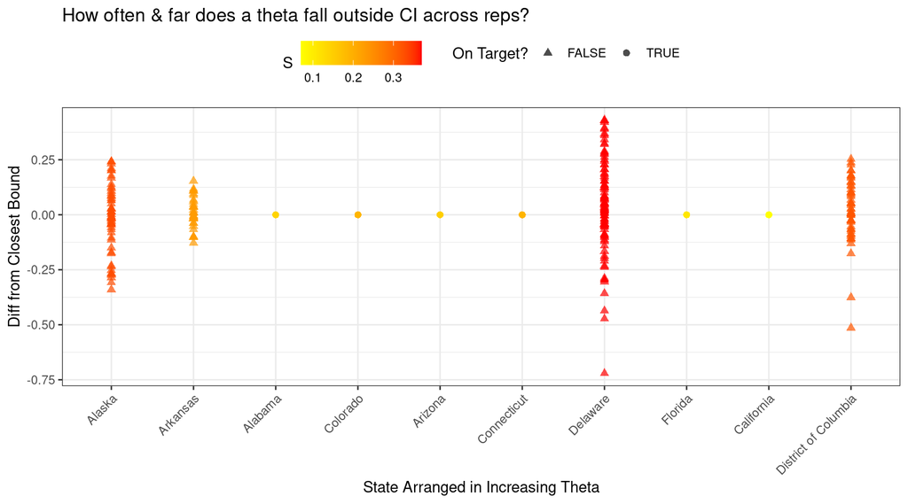

#### 1.3.0.2 K = 20

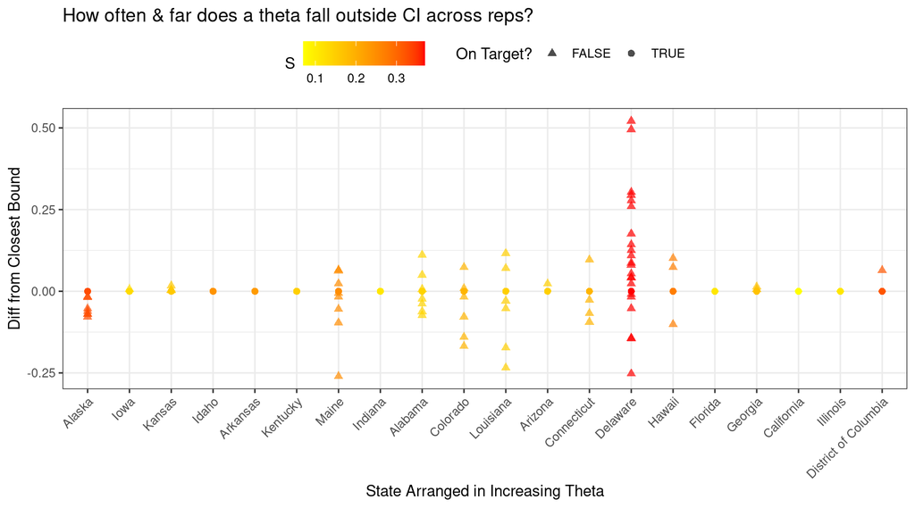

#### 1.3.0.3 K = 30

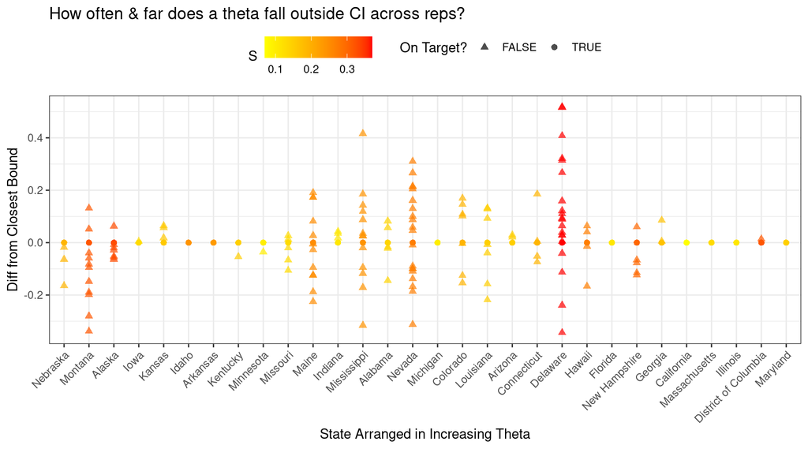

#### 1.3.0.4 K = 40

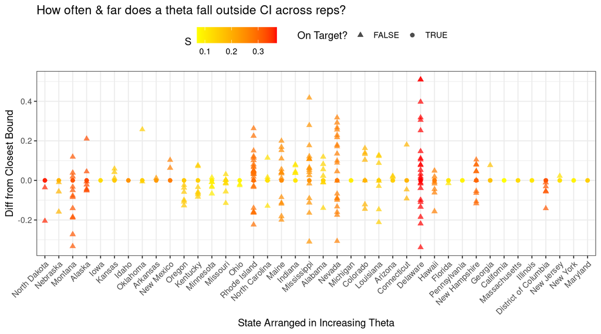

#### 1.3.0.5 K = 51

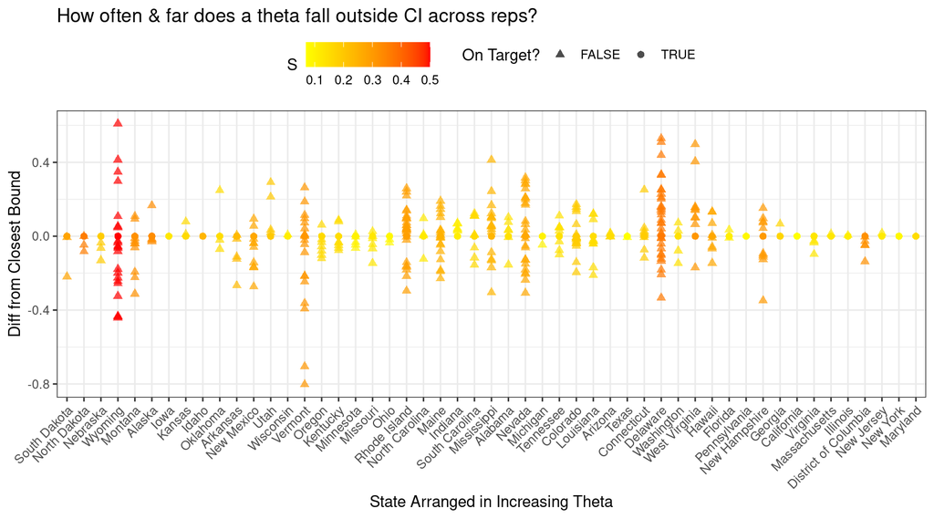

### 1.3.1 Results from **5000** reps

```r
library(dplyr)
library(kableExtra)
Ks <- c(51, 40, 30, 20, 10)

results <- lapply(Ks, function(K) {
  a <- readRDS(paste0("../output/coverage_probability_", K, ".rds"))
  #a <- readRDS(paste0("../output/coverage_probability_", K, ".rds"))
  #print(a)
  data.frame(
    K = K,
    Coverage = mean(a$inside_check_1 == K),  # only TRUE if inside == K
    Within_CI_mean = mean(a$inside_check_2),
    Within_CI_max = max(a$inside_check_2),
    Within_CI_min = min(a$inside_check_2),
    T_mean = mean(a$t2)
  )
})

df <- do.call(rbind, results)

kable(df) %>% kable_styling(bootstrap_options = "responsive")
```

| K | Coverage | Within_CI_mean | Within_CI_max | Within_CI_min | T_mean |
| --- | --- | --- | --- | --- | --- |
| 51 | 0.9510 | 50.9508 | 51 | 49 | 14.282420 |
| 40 | 0.9760 | 39.9760 | 40 | 39 | 11.035062 |
| 30 | 0.9864 | 29.9864 | 30 | 29 | 8.711721 |
| 20 | 0.9830 | 19.9830 | 20 | 19 | 6.215027 |
| 10 | 0.9712 | 9.9710 | 10 | 8 | 3.281081 |

### Results for different alpha, **100** reps - to redo

```r
library(dplyr)
final_results <- readRDS("../output/test/coverage_probability_all.rds")
prepped <- final_results %>%
  mutate(ft = K==inside_check_1) %>%
  select(alpha, K, ft, t2) %>%
  group_by(alpha, K) %>%
  summarise(cov = mean(ft), mean_t2 = mean(t2)) %>%
  arrange(K)


kable(prepped) %>% kable_styling(bootstrap_options = "responsive")
```

| alpha | K | cov | mean_t2 |
| --- | --- | --- | --- |
| 0.01 | 10 | 0.82 | 2.338389 |
| 0.05 | 10 | 0.75 | 2.158797 |
| 0.10 | 10 | 0.63 | 2.074114 |
| 0.01 | 20 | 0.73 | 3.759947 |
| 0.05 | 20 | 0.59 | 3.439172 |
| 0.10 | 20 | 0.50 | 3.239371 |
| 0.01 | 30 | 0.41 | 5.109571 |
| 0.05 | 30 | 0.30 | 4.764164 |
| 0.10 | 30 | 0.25 | 4.491803 |
| 0.01 | 40 | 0.14 | 5.715800 |
| 0.05 | 40 | 0.10 | 5.436368 |
| 0.10 | 40 | 0.10 | 5.139313 |
| 0.01 | 51 | 0.03 | 6.912486 |
| 0.05 | 51 | 0.03 | 6.700447 |
| 0.10 | 51 | 0.00 | 6.354419 |

### 1.3.2 Breakdown of within CI per K

```r
Ks <- c(51, 40, 30, 20, 10)

results <- lapply(Ks, function(K) {
  # "../output/coverage_probability_"
  fname <- "../output/coverage_probability_"
  a <- readRDS(paste0(fname, K, ".rds"))
  data.frame(K = K, inside = a$inside_check_1)
})

df_all <- do.call(rbind, results)

summary_counts <- df_all %>%
  group_by(K, inside) %>% summarise(count = n(), .groups = "drop_last") %>% mutate(proportion = count / sum(count)) %>%
  ungroup()

summary_counts %>%
  kable(align = "c") %>%
  kable_styling(bootstrap_options = "striped", full_width = FALSE) %>%
  row_spec(which(summary_counts$K == summary_counts$inside), background = "lightyellow")
```

| K | inside | count | proportion |
| --- | --- | --- | --- |
| 10 | 8 | 1 | 0.0002 |
| 10 | 9 | 143 | 0.0286 |
| 10 | 10 | 4856 | 0.9712 |
| 20 | 19 | 85 | 0.0170 |
| 20 | 20 | 4915 | 0.9830 |
| 30 | 29 | 68 | 0.0136 |
| 30 | 30 | 4932 | 0.9864 |
| 40 | 39 | 120 | 0.0240 |
| 40 | 40 | 4880 | 0.9760 |
| 51 | 49 | 1 | 0.0002 |
| 51 | 50 | 244 | 0.0488 |
| 51 | 51 | 4755 | 0.9510 |

### Experimental runs results

- K = 10, 100 reps, cov: changing rstar from `rstar <- sorted_thetahat_star - matrix(sorted_theta_hat,B, K, byrow=TRUE)` to `rstar <- sweep(sorted_thetahat_star, 2, colMeans(sorted_thetahat_star), FUN = "-")` increased coverage by ~0.10
- K = 51, 100 reps, cov: changing rstar from `rstar <- sorted_thetahat_star - matrix(sorted_theta_hat,B, K, byrow=TRUE)` to `rstar <- sweep(sorted_thetahat_star, 2, colMeans(sorted_thetahat_star), FUN = "-")` increased coverage by ~0.06
- simple dgp via `generate_synthetic_dataset` produced close to expected result
- Using ecdf instead of pnorm did not change the coverage for K=10

### Experimental runs results - to redo

#### SD

Notes:  
0.14 0.33 0.15 0.23 0.07 0.19 0.19 0.37 0.32 0.11  
original SDs: 0.23

SD set to 0.2 (fixed), coverage: 0.77  
SD set to rnorm(n, 0.2, 0.001), coverage: 0.77  
SD set to rnorm(n, 0.2, 0.01), coverage: 0.77  
SD set to rnorm(n, 0.2, 0.1), coverage: 0.39

SD set to 0.1 (fixed), coverage: 0.86  
SD set to rnorm(n, 0.1, 0.001), coverage: 0.86  
SD set to rnorm(n, 0.1, 0.01), coverage: 0.83

SD set to 0.5 (fixed), coverage: 0.52  
SD set to rnorm(n, 0.5, 0.001), coverage: 0.52  
SD set to rnorm(n, 0.5, 0.01), coverage: 0.5  
SD set to rnorm(n, 0.5, 0.1), coverage: 0.43

0.14 0.33 0.15 0.23 0.07 0.19 0.19 0.37 0.32 0.11  
original SDs: 0.23

SD set to runif(dim(df)[1], 0.1, 0.6): 0.24  
SD set to runif(dim(df)[1], 0.1, 0.5): 0.28 <- min max of K=51 is used  
SD set to runif(dim(df)[1], 0.07, 0.37): 0.28 <- min max of K=10 is used  
SD set to runif(dim(df)[1], 0.1, 0.4): 0.33  
SD set to runif(dim(df)[1], 0.1, 0.3): 0.41  
SD set to runif(dim(df)[1], 0.1, 0.2): 0.55

SD set to 0.1 (fixed), coverage: 0.86 <- fixed higher  
SD set to 0.05 (fixed), coverage: 0.91 <- fixed higher  
SD set to runif(dim(df)[1], 0.05, 0.06): 0.87 <- narrower  
SD set to runif(dim(df)[1], 0.05, 0.1): 0.64 <- broader

Seems like when SD across varies highly across items to rank, leads to lower coverage, besides the extremeness of the SD themselves